# Prosper Loan

## by (Omar Adel)

## Investigation Overview

> The goal of my investigation is to look at the aspects of each loan amount, and figure out what factors influence prosper loans, it's borrorwer's interest rate and the lender yield.

## Dataset Overview

> This data set contains several loans with many variables on each loan, including loan amount, borrower rate (or interest rate), current loan status, borrower income, and many others.

## Income Range

> 1. We can observe two trends. The first one is the majority of borrowers applying for loans have an income range between 25k to 75k with Income Range between 50 to 75 in the first place.
> 2. The Second trend is between 75k to 100+.

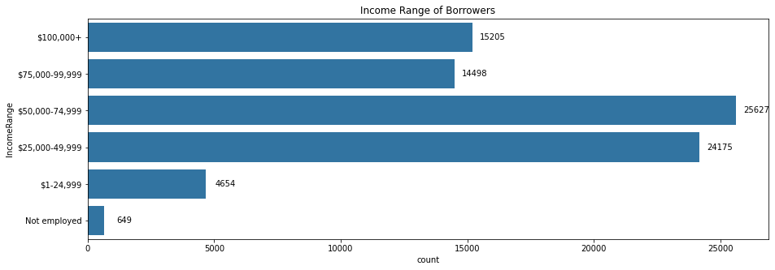

## Borrower Interest Rate

> TThe plot is almost normally distributed with a spike in interest rate of 32% with interest rates ranged between 0.10 and 0.25

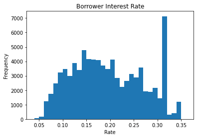

## Do monthly payments increase by the increase in loan amounts?

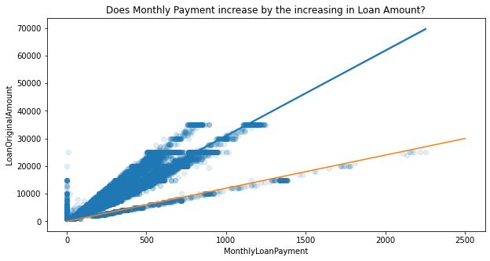

## Does borrower income range affect the term (duration) of the loan?

> We can observe that if you have a high income range that doesn't necessarily mean that you're going for a high term loan. 36 Term has the most count values then comes 60. People with Income Range between 25k and 75k tend to get a loan that has a duration of 36 months. Same goes for each Income Range category.

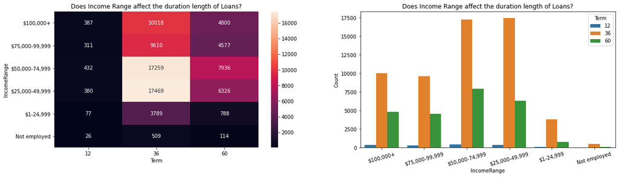

## Does Stated Monthly Income affect the Monthly Loan Payment or Loan Original Amount?

> We can observe that there's a positive relationship between Monthly Loan Payment and Loan Original Amount. The relationship between stated monthly income and either loan original amount is weak positive relationship which means that stated monthly income has very low effect on Loan Original Amount or Monthly Loan Payment. Most of the values are between 0 and 0.1.

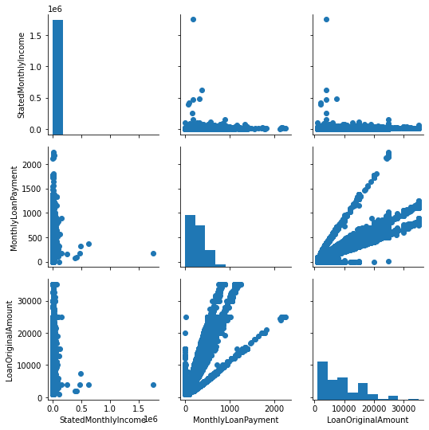

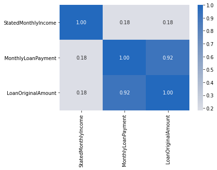